# TreeClassification-HighRes-IndividualUser

Aitor Apaolaza

12/01/2016

*Copyright (c) 2015 The University of Manchester, UK.*

*Licenced under LGPL version 2.1. See LICENCE for details.*

*The IDInteraction Attention Classification was developed in the IDInteraction project, funded by the Engineering and Physical Sciences Research Council, UK through grant agreement number EP/M017133/1.*

*Author: Aitor Apaolaza*

## Initialisation and loading data

```
## [1] "All listed packages are already installed"
```

# Setup for the classification algorithm.

**Folder**: /home/aitor/Dropbox/UoM/IDInteractionCode/Rnotebooks

**Experiment**: dual_screen_free_experiment

**Source Videos**: high_quality

**Tracking system**: front_full_face

**Using the following list of participants**: P10.

**Using the following timelimit threshold to separate training and testing data**: 10.

Data for these participants will be read from the CSV files contained in the following folders:

/home/aitor/Dropbox/UoM/IDInteractionCode/Rnotebooks/resources/dual_screen_free_experiment/high_quality/attention/

/home/aitor/Dropbox/UoM/IDInteractionCode/Rnotebooks/resources/dual_screen_free_experiment/high_quality/front_full_face/

Loading data for participant P10

```
## [1] "Processing participant: P10"
## [1] "START of combineCSVsToDF()"
## [1] "END of combineCSVsToDF()"
## [1] "START of createFeatureDF()"
## [1] "END of createFeatureDF()"
```

## Training the tree classifier

Using the **rpart** library for the following formula:

**attentionName ~ boxHeight + boxRotation + boxArea + boxWidth + widthHeightRatio + boxYcoordRel**

Resulting model:

```
## n= 29707
##
## node), split, n, loss, yval, (yprob)
##       * denotes terminal node
##
##   1) root 29707 7971 tv (0.003904804 0.264415794 0.731679402)
##     2) boxYcoordRel< 0.2306082 21729 7757 tv (0.005338488 0.351649869 0.643011643)
##       4) boxYcoordRel>=0.1499327 17399 7315 tv (0.000000000 0.420426461 0.579573539)
##         8) boxHeight< 101.4165 2628  452 ipad (0.000000000 0.828006088 0.171993912)
##          16) boxHeight>=26.00325 2295  177 ipad (0.000000000 0.922875817 0.077124183) *
##          17) boxHeight< 26.00325 333   58 tv (0.000000000 0.174174174 0.825825826) *
##         9) boxHeight>=101.4165 14771 5139 tv (0.000000000 0.347911448 0.652088552)
##          18) boxYcoordRel< 0.2152885 11281 4402 tv (0.000000000 0.390213634 0.609786366)
##            36) boxHeight< 162.4285 1032  229 ipad (0.000000000 0.778100775 0.221899225)
##              72) boxRotation>=-7.370815 796   48 ipad (0.000000000 0.939698492 0.060301508) *
##              73) boxRotation< -7.370815 236   55 tv (0.000000000 0.233050847 0.766949153) *
##            37) boxHeight>=162.4285 10249 3599 tv (0.000000000 0.351156210 0.648843790)
##              74) boxHeight>=257.7775 7433 2860 tv (0.000000000 0.384770618 0.615229382)
##               148) boxYcoordRel>=0.205993 2060  822 ipad (0.000000000 0.600970874 0.399029126)
##                 296) boxHeight< 293.411 1538  446 ipad (0.000000000 0.710013004 0.289986996) *
##                 297) boxHeight>=293.411 522  146 tv (0.000000000 0.279693487 0.720306513) *
##               149) boxYcoordRel< 0.205993 5373 1622 tv (0.000000000 0.301879769 0.698120231)
##                 298) boxRotation>=2.21726 544  236 ipad (0.000000000 0.566176471 0.433823529)
##                   596) boxYcoordRel>=0.2028997 371   99 ipad (0.000000000 0.733153639 0.266846361) *
##                   597) boxYcoordRel< 0.2028997 173   36 tv (0.000000000 0.208092486 0.791907514) *
##                 299) boxRotation< 2.21726 4829 1314 tv (0.000000000 0.272106026 0.727893974) *
##              75) boxHeight< 257.7775 2816  739 tv (0.000000000 0.262428977 0.737571023)
##               150) boxHeight< 179.8285 1073  472 tv (0.000000000 0.439888164 0.560111836)
##                 300) boxYcoordRel< 0.2109328 331   28 ipad (0.000000000 0.915407855 0.084592145) *
##                 301) boxYcoordRel>=0.2109328 742  169 tv (0.000000000 0.227762803 0.772237197) *
##               151) boxHeight>=179.8285 1743  267 tv (0.000000000 0.153184165 0.846815835) *
##          19) boxYcoordRel>=0.2152885 3490  737 tv (0.000000000 0.211174785 0.788825215) *
##       5) boxYcoordRel< 0.1499327 4330  442 tv (0.026789838 0.075288684 0.897921478) *
##     3) boxYcoordRel>=0.2306082 7978  214 tv (0.000000000 0.026823765 0.973176235)
##       6) boxHeight< 77.3459 136   16 ipad (0.000000000 0.882352941 0.117647059) *
##       7) boxHeight>=77.3459 7842   94 tv (0.000000000 0.011986738 0.988013262) *
```

From the R manual for the Complexity Parameter Table for an Rpart Fit: *The cptable in the fit contains the mean and standard deviation of the errors in the cross-validated prediction against each of the geometric means.*

Matrix of information on the optimal prunings based on a complexity parameter.

```
##
## Classification tree:
## rpart(formula = formula, data = trainsetclass, method = "class")
##
## Variables actually used in tree construction:
## [1] boxHeight    boxRotation  boxYcoordRel
##
## Root node error: 7971/29707 = 0.26832
##
## n= 29707
##
##         CP nsplit rel error  xerror      xstd
## 1 0.072095      0   1.00000 1.00000 0.0095808
## 2 0.036006      3   0.78372 0.78422 0.0088137
## 3 0.027224      5   0.71170 0.71434 0.0085112
## 4 0.026095      6   0.68448 0.69602 0.0084269
## 5 0.017250      9   0.60344 0.59729 0.0079324
## 6 0.015807     11   0.56894 0.57421 0.0078063
## 7 0.013047     12   0.55313 0.54937 0.0076656
## 8 0.010852     13   0.54008 0.54247 0.0076256
## 9 0.010000     15   0.51838 0.52616 0.0075293
```

Visualisation of the Complexity Parameter Table. *A good choice of cp for pruning is often the leftmost value for which the mean lies below the horizontal line.*

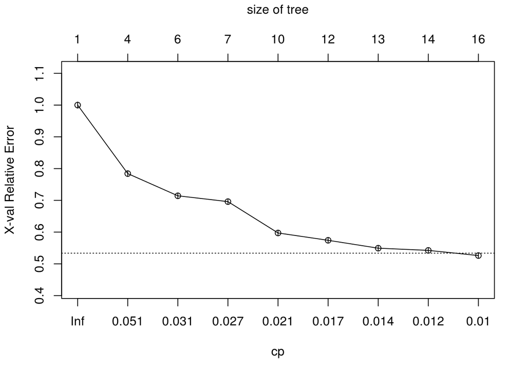

## Tree

### Summary of the tree

```
##
## Model formula:
## attentionName ~ boxHeight + boxRotation + boxArea + boxWidth +
##     widthHeightRatio + boxYcoordRel
##
## Fitted party:
## [1] root
## |   [2] boxYcoordRel < 0.23061
## |   |   [3] boxYcoordRel >= 0.14993
## |   |   |   [4] boxHeight < 101.4165
## |   |   |   |   [5] boxHeight >= 26.00325: ipad (n = 2295, err = 7.7%)
## |   |   |   |   [6] boxHeight < 26.00325: tv (n = 333, err = 17.4%)
## |   |   |   [7] boxHeight >= 101.4165
## |   |   |   |   [8] boxYcoordRel < 0.21529
## |   |   |   |   |   [9] boxHeight < 162.4285
## |   |   |   |   |   |   [10] boxRotation >= -7.37082: ipad (n = 796, err = 6.0%)
## |   |   |   |   |   |   [11] boxRotation < -7.37082: tv (n = 236, err = 23.3%)
## |   |   |   |   |   [12] boxHeight >= 162.4285
## |   |   |   |   |   |   [13] boxHeight >= 257.7775
## |   |   |   |   |   |   |   [14] boxYcoordRel >= 0.20599
## |   |   |   |   |   |   |   |   [15] boxHeight < 293.411: ipad (n = 1538, err = 29.0%)
## |   |   |   |   |   |   |   |   [16] boxHeight >= 293.411: tv (n = 522, err = 28.0%)
## |   |   |   |   |   |   |   [17] boxYcoordRel < 0.20599
## |   |   |   |   |   |   |   |   [18] boxRotation >= 2.21726
## |   |   |   |   |   |   |   |   |   [19] boxYcoordRel >= 0.2029: ipad (n = 371, err = 26.7%)
## |   |   |   |   |   |   |   |   |   [20] boxYcoordRel < 0.2029: tv (n = 173, err = 20.8%)
## |   |   |   |   |   |   |   |   [21] boxRotation < 2.21726: tv (n = 4829, err = 27.2%)
## |   |   |   |   |   |   [22] boxHeight < 257.7775
## |   |   |   |   |   |   |   [23] boxHeight < 179.8285
## |   |   |   |   |   |   |   |   [24] boxYcoordRel < 0.21093: ipad (n = 331, err = 8.5%)
## |   |   |   |   |   |   |   |   [25] boxYcoordRel >= 0.21093: tv (n = 742, err = 22.8%)
## |   |   |   |   |   |   |   [26] boxHeight >= 179.8285: tv (n = 1743, err = 15.3%)
## |   |   |   |   [27] boxYcoordRel >= 0.21529: tv (n = 3490, err = 21.1%)
## |   |   [28] boxYcoordRel < 0.14993: tv (n = 4330, err = 10.2%)
## |   [29] boxYcoordRel >= 0.23061
## |   |   [30] boxHeight < 77.3459: ipad (n = 136, err = 11.8%)
## |   |   [31] boxHeight >= 77.3459: tv (n = 7842, err = 1.2%)
##
## Number of inner nodes:    15
## Number of terminal nodes: 16
```

### Visualisation of the tree

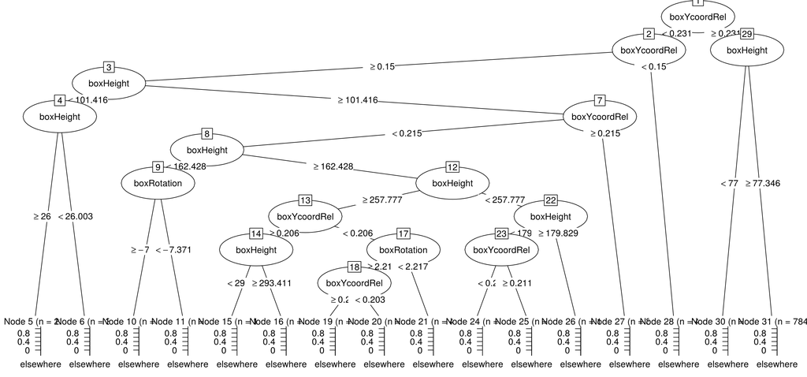

Tree classifier plot

## Error metrics analysis

Confusion matrix from the application of the tree predictor to the testing set of data.

```
##            predclass
##             elsewhere ipad   tv
##   elsewhere         0    0    0
##   ipad              0 2008  656
##   tv                0 5018 7994
```

### Error metrics based on prediction of attention to the iPad.

True negatives: 7994

False negatives: 5018

True positives: 2008

False positives: 656

**Error-rate**: the proportion of the incorrectly classified examples -> (fp+fn)/(tp+tn+fp+tn)

**36.195458**

**Accuracy**: the proportion of the correctly classified examples -> (tp+tn)/(tp+tn+fp+tn)

**63.804542**

As the number of instances of the response variable is not balanced (there are many more instances with false than true) the accuracy is not a good indicator. Other cost sensitive measures are reported here. -> cost sensitive measures

**Precision**: positive predicted value (PPV) -> tp/(tp+fp), a measure of exactness

**75.3753754**

**Recall/Sensitivity**: true positive recognition rate -> tp/(tp+fn), a measure of completeness

**28.5795616**

**Specificity**: true negative recognition rate -> tn/(tn+fp)

**92.416185**

**F measure**: the balance between precision and recall -> 2*tp/(2*tp+fp+fn)

**41.4447884**

# ERROR MEASURES INLINE COPY

P10 **36.195458** **63.804542** **75.3753754** **28.5795616** **92.416185** **41.4447884**

### Error metrics based on prediction of attention to the TV.

True negatives: 2008

False negatives: 656

True positives: 7994

False positives: 5018

**Error-rate**: the proportion of the incorrectly classified examples -> (fp+fn)/(tp+tn+fp+tn)

**36.195458**

**Accuracy**: the proportion of the correctly classified examples -> (tp+tn)/(tp+tn+fp+tn)

**63.804542**

**Precision**: positive predicted value (PPV) -> tp/(tp+fp), a measure of exactness

**61.4355979**

**Recall/Sensitivity**: true positive recognition rate -> tp/(tp+fn), a measure of completeness

**92.416185**

**Specificity**: true negative recognition rate -> tn/(tn+fp)

**28.5795616**

**F measure**: the balance between precision and recall -> 2*tp/(2*tp+fp+fn)

**73.8066661**